# ScReNI tutorial

xueli xu

2024-10-15

# Installation

Follow the steps below to install ScReNI package from GitHub and run it:

```r
install.packages('devtools')
devtools::install_github('Xuxl2020/ScReNI')

# require
library(ScReNI)
```

```r
# load requried packages
library(Seurat) # remotes::install_version("Seurat", "5.0.1", repos = c("https://satijalab.r-universe.dev", getOption("repos")))
library(SeuratObject) # remotes::install_version("SeuratObject", "5.0.1", repos = c("https://satijalab.r-universe.dev", getOption("repos")))
library(Signac) # 1.10.0
library(dplyr)
library(ggpubr)
library(monocle3)
library(ggplot2)
library(igraph)
library(Matrix) ###remotes::install_version("Matrix", version = "1.6-5")
library(harmony) ###remotes::install_version("harmony", version = "0.1.1")
library(sctransform) ###remotes::install_version("sctransform", version = "0.4.1")
library(GenomeInfoDb)
library(BSgenome.Mmusculus.UCSC.mm10)
library(EnsDb.Mmusculus.v79)
library(ComplexHeatmap)
library(IReNA)
library(patchwork)
library(future)
library(cowplot)
```

# Introduction

ScReNI infers the regulatory network for each cell through integrating unpaired scRNA-seq and scATAC-seq data. This comprehensive tutorial is structured into five steps: (1) Clustering Integration; (2) Inference of Single Cell-Specific Networks; (3) Evaluation of Regulatory Networks; (4) Cell Clustering Based on Networks; (5) Identification of Cell-enriched Regulators.

# Input Data

Seurat objects and intermediate files can be accessed and downloaded through the following link: [Datasets](https://drive.google.com/drive/folders/1SJYbxeFk8z6Ac9bRJTdbtTJ9y-M4HsHf?usp=drive_link) Please ensure that the Seurat object is properly formatted and includes all necessary metadata for accurate analysis.

```r
# Define data information
data.name = 'mmRetina_RPCMG'
species = 'mouse'
data.type = 'unpaired'
```

```r
# Please set your path
path = 'data/'
scRNAseq <- readRDS(paste0(path, data.name, "_scRNAseq.rds"))
scATACseq <- readRDS(paste0(path, data.name, "_scATACseq.rds"))
```

# Step 1: perform clustering to integrate scRNA-seq and scATAC-seq data

```r
# Step 1.1: integrate scRNA-seq and scATAC-seq
# Define integration parameters
IntegratedDimensions <- 20
KNN <- 20
AnchorsDim <- 50
# for unpaired scRNA-seq and scATAC-seq data
coembed <- Integrate_scRNA_scATAC(scRNAseq, scATACseq, AnchorsDim, IntegratedDimensions, KNN, data.type='unpaired')
# for paired scRNA-seq and scATAC-seq data
# coembed <- Integrate_scRNA_scATAC(scRNAseq, scATACseq, IntegratedDimensions, KNN, data.type='paired', species)
```

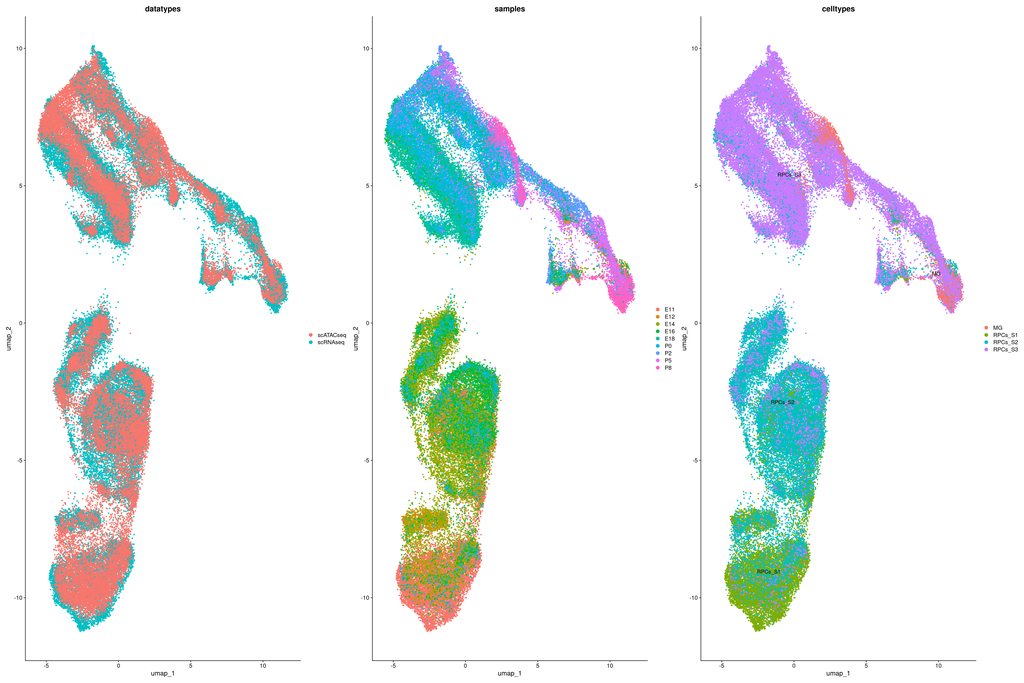

```r
# Step 1.2: plot figures for the integrated scRNAseq and scATACseq
coembed <- readRDS('data/mmRetina_RPCMG_integrated_scRNA_scATAC_D30.rds')
groups=c('datatypes', 'samples', 'celltypes')
print(DimPlot(coembed, group.by = groups[1], reduction = "umap", pt.size = 0.8, label = F)
      |DimPlot(coembed, group.by = groups[2], reduction = "umap", pt.size = 0.8, label = F)
      |DimPlot(coembed, group.by = groups[3], reduction = "umap", pt.size = 0.8, label = T))
```

```r
# Step 1.3 only for unpaired data: get the nearest neighbor of each cell. However, for paired data, step 1.3 is not necessary. Instead, you can proceed directly to step 2 of the analysis pipeline.
scRNA_scATAC_neighbor <- Get_scRNA_scATAC_neighbors(coembed)
scRNA_scATAC_neighbor_dup <- scRNA_scATAC_neighbor[[1]]
scRNA_scATAC_neighbor_undup <- scRNA_scATAC_neighbor[[2]]
```

# Step 2: infer single cell-specific networks

kScReNI infers cell-specific regulatory networks using transcriptomes alone. wScReNI infers cell-specific regulatory networks by integrating scRNA-seq and scATAC-seq data.

```r
# set the parameters
cell.num = 100 # number of each cell type
ngenes = 500 # number of highly variable genes
npeaks = 10000 #  number of highly variable peaks
result.path = 'results/' # please set the result path
network.path = paste0(result.path, 'NetworksC', cell.num, '/')  # the path to save networks
```

```r
# Step 2.1: get partial cells to infer scNetworks
# partial cells
Partial_cell <- c("RPCs_S1", "RPCs_S2", "RPCs_S3", "MG")
# for unpaired data
scRNA.scATAC.cells <- Select_partial_cells_for_scNewtorks(coembed, Partial_cell, cell.num, data.type = "unpaired", scRNA_scATAC_neighbor_undup)
# for paired data
# scRNA.scATAC.cells <- Select_partial_cells_for_scNewtorks(coembed, Partial_cell, cell.num, data.type = "paired")
```

```r
# Step 2.2: select top variable genes and peaks to infer scNetworks
sub.scrna.top <- select_features(sub.scrna, ngenes, datatype='RNA')
sub.scatac.top <- select_features(sub.scatac, npeaks, datatype='ATAC')
```

```r
# Step 2.3: infer scNetworks using kScReNI
kScReNI.weights <- Infer_kScReNI_scNetworks(sub.scrna.top, ngenes, knn=KNN)
```

When employing wScReNI, it is essential to leverage reference datasets. These datasets can be conveniently accessed and downloaded via the following link: [Reference dataset](https://drive.google.com/drive/folders/12a_SQjrdjUU6fx_En42GYguuch0DP8zQ?usp=drive_link). They serve as an indispensable resource for deciphering the intricate connections between genes and peaks, a fundamental step in the construction of regulatory networks. However, if you have prior knowledge of the specific relationships between genes and peaks, you can proceed directly to Step 2.4.2 of the network construction phase.

```r
# Step 2.4: infer scNetworks using wScReNI
# Step 2.4.1: identification of peak-associated genes
library(BSgenome.Mmusculus.UCSC.mm10) ### 1.4.3
genome_database = BSgenome.Mmusculus.UCSC.mm10
motif_database <- read.table("Tranfac201803_Mm_MotifTFsFinal.txt", header = T)
gtf_data <- as.data.frame(rtracklayer::import("mouse.genes.gtf"))
motif_pwm <- readRDS("all_motif_pwm.rds")

gene_peak_overlap <- Infer_gene_peak_relationships(gtf_data,
                                                   sub.scrna.top,
                                                   sub.scatac.top,
                                                   motif_database,
                                                   motif_pwm,
                                                   genome_database = genome_database)

gene_peak_overlap_matrix <- peakMat(sub.scatac.top, gene_peak_overlap)
gene_peak_overlap_labs <- peak_gene_TF_labs(gene_peak_overlap)
```

```r
# Step 2.4.2: get the nearest neighbor of each cell
scRNA_scATAC_WNN <- Integrate_scRNA_scATAC(sub.scrna.top, sub.scatac.top, IntegratedDimensions=20, KNN, data.type='paired')
nearest.neighbors.idx <- scRNA_scATAC_WNN[['weighted.nn']]@nn.idx
rownames(nearest.neighbors.idx) <- scRNA_scATAC_WNN[['weighted.nn']]@cell.names
```

```r
# Step 2.4.3: infer scNetworks using wScReNI
wScReNI.weights <- Infer_wScReNI_scNetworks(sub.scrna.top, gene_peak_overlap_matrix, gene_peak_overlap_labs, nearest.neighbors.idx, network.path, data.name, cell.index=1:400)
wScReNI.weights <- Combine_wScReNI_scNetworks(sub.scrna.top, network.path)
```

# Step 3: evaluation of the precision and recall on regulatory networks

ChIP-atlas was used to assess the inferred regulatory relationships. This dataset serves as a valuable reference for evaluating the performance of different network inference methods. Precision and recall serve as metrics for evaluating the performance of different single-cell regulatory network inference methods.

```r
# Read the relationships of gene ID and gene symbol based on species
Gene_gtf_information <- 'gtf_region.10X_Mouse_ref'
ChIP_atlas <- 'mmp9.TSV.5kb_TF_target.df'

gtf_regions <- read.table(paste0('refer/', Gene_gtf_information, ".txt"), sep = "\t", header = T)
gene_id_gene_name_pair <- Deal_gene_information(gtf_regions)

# Read TF-target pairs from ChIP Atlas
TF_target <-read.table(paste0('refer/', ChIP_atlas, ".txt"), sep="\t")
TF_target_pair <- unique(paste(TF_target[, 1], TF_target[, 2], sep="_"))
```

```r
# For example, we infer scNetworks using CSN, CeSpGRN, LIONESS, kScReNI, and wScReNI.
# make sure the first element of scNetworks is from CSN
scNetworks <- list(CSN, CeSpGRN.weights, LIONESS.weights, kScReNI.weights, wScReNI.weights)
names(scNetworks) <- c('CSN', 'CeSpGRN', 'LIONESS', 'kScReNI', 'wScReNI')

# Set the parameters
top_number = c(1000, seq(2000, 10000, by=2000), 20000)

# Calculate the precision and recall
scNetworks_precision_recall <- Calculate_scNetwork_precision_recall(scNetworks, TF_target_pair, top_number)
scNetworks_precision_recall_noCSN <- scNetworks_precision_recall[-1]
scNetworks_precision_recall_top <- Calculate_scNetwork_precision_recall_top(scNetworks_precision_recall_noCSN, top_number)
```

# Step 4: perform cell clustering based on single cell-specific networks

For the purpose of network-based cell clustering, we calculated gene degrees derived from cell-specific networks. To evaluate the influence of the number of pairwise relationships between TFs and target genes, we applied diverse thresholds to the ranked weights.

```r
# Step 4.1: Calculate the degrees
ncell = 400; ntype = 4; top = rep(500, ncell) # top 500 gene regulation pairs
celltype <- read.csv(paste0('data/', data.name, "_Cell", cell.num, "_annotation.csv"))
sub.celltype <- celltype$undup.cell.types
```

```r
scNetworks_degree <- calculate_scNetwork_degree(scNetworks, top, sub.celltype, ntype, column_name='sub.celltype')
```

```r
# Step 4.2: Plot cell clustering based on the networks
load('data/scNetworks_degree.rdata')
col = list(Cell_type = c("MG" = "red", "RPCs_S1" = "green", "RPCs_S2" = "blue", "RPCs_S3" = "purple"))
Network_types <- names(scNetworks_degree)
i=3
print(Network_types[i])
```

```
## [1] "kScReNI"
```

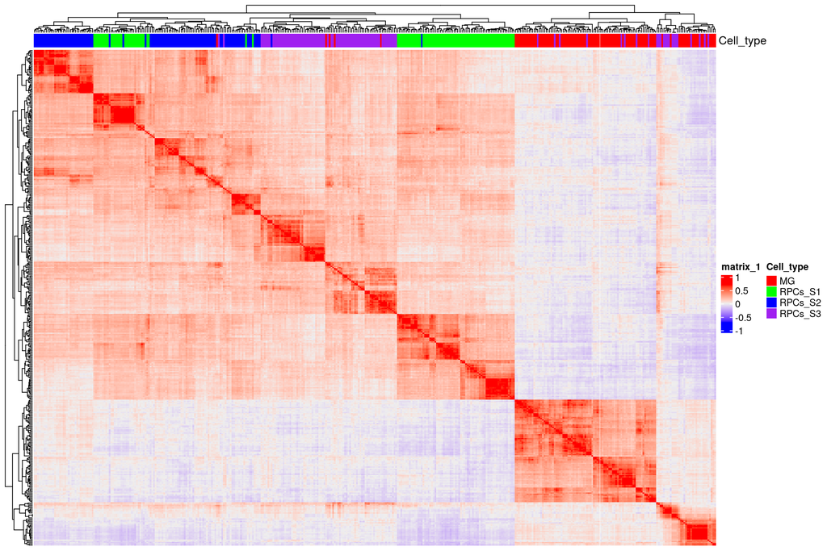

```r
degree <- scNetworks_degree[[i]]
outdegree <- degree[['outdegree']]
out.degree <- degree[['out.degree.umap']]
# plot the heatmap based on the similarity of the degree matrix
column_ha = HeatmapAnnotation("Cell_type" = sub.celltype, col = col)
Heatmap(cor(log(outdegree+1)),
                top_annotation = column_ha,
                show_row_names = F,
                show_column_names = F)
```

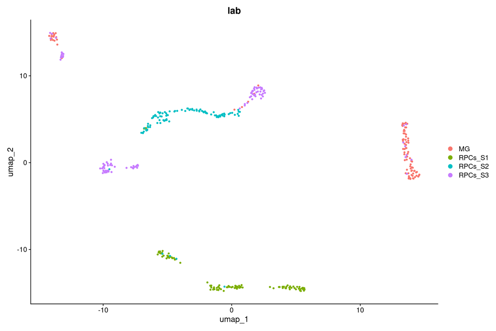

```r
out.degree[['lab']] <- sub.celltype
DimPlot(out.degree, reduction = "umap", group.by = "lab", label = F)
```

```r
i=5
print(Network_types[i])
```

```
## [1] "wScReNI"
```

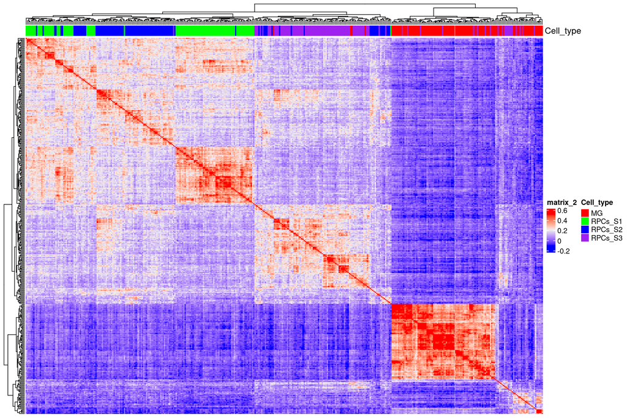

```r
degree <- scNetworks_degree[[i]]
outdegree <- degree[['outdegree']]
out.degree <- degree[['out.degree.umap']]
# plot the heatmap based on the similarity of the degree matrix
column_ha = HeatmapAnnotation("Cell_type" = sub.celltype, col = col)
Heatmap(cor(log(outdegree+1)),
                top_annotation = column_ha,
                show_row_names = F,
                show_column_names = F)
```

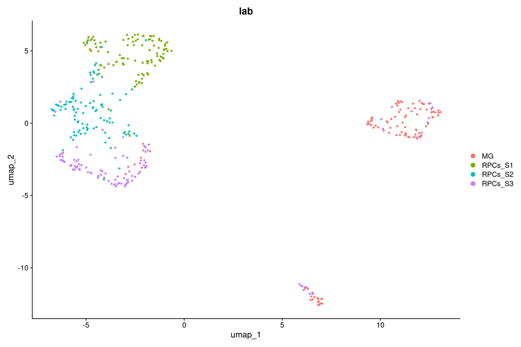

```r
out.degree[['lab']] <- sub.celltype
DimPlot(out.degree, reduction = "umap", group.by = "lab", label = F)
```